# Esercizio2

Michele Luca Puzzo

11/25/2021

## 2.1

To have a legit density I have to impose that the approximating density is greater than 0 for each x belonging to the support $S_X = [0,1]$. Moreover the integral of the approximating density over all the support has to be equal to 1.

$\hat{f}(x, 𝚹) > 0 \hspace{0.2cm} \forall x \in S_x$

The indicator function can be equal to 0 or 1 and h is a length so it is greater than zero so:

$$\sum_{j=1}^N \frac{\pi_j}{h} \mathbb{I(x \in B_j)}>0 \Rightarrow \pi_j > 0 \hspace{0.2cm} \forall j \in \{1,..,N\}$$
$\int_{\mathbb {R}}\hat{f}(x, 𝚹)dx = 1$

I exploit the additivity of the integral respect to the extremes:

$$\int_{0}^{1}\sum_{j=1}^N \frac{\pi_j}{h} \mathbb{I(x \in B_j)} dx = \int_{0}^{h}\sum_{j=1}^N \frac{\pi_j}{h} \mathbb{I(x \in B_j)} dx + \int_{h}^{2h}\sum_{j=1}^N \frac{\pi_j}{h} \mathbb{I(x \in B_j)} dx + ... + \int_{1-h}^{1}\sum_{j=1}^N \frac{\pi_j}{h} \mathbb{I(x \in B_j)} dx = \frac{\pi_1}{h} \cdot h + \frac{\pi_2}{h}\cdot h+ ...+\frac{\pi_N}{h}\cdot h = 1$$
In conclusion the constraints that we have obtained, given a fixed h, over the parameter vector ($\pi_1, \pi_2, ... \pi_N$) are:

- $\pi_j > 0 \hspace{0.2cm} \forall j \in \{1,..,N\}$
- $\sum_{j=1}^N \pi_j= 1$

So we have obtained that each parameter $\pi_j$ has to be greater than zero and their sum has to be equal to one.

## 2.2

We have implemented the approximating density using a *for loop* and an *if-else condition* to realize the indicator function. When we find the bin corresponding to the x we interrupt the cycle, because it is useless to check all the bins. In our convention a generic bin is an interval left closed and right open except the last one, for example the first is [0,h). The number of bins N has to be an integer number: we have used the function *ceiling* knowing that the last bin could be shorter because 1/h could be not integer.

```r
#pigreco is a list of N parameters, h is a fixed parameter
approx_f <- function(h, x, pigreco){

  #input:
  #h: length of the bin
  #x: point in which we want to compute the function
  #pigreco: vector of parameter

  #output: approximating function computed in x

  #computing number of bins, the last bin could be shorter (hence the ceiling)
  N = ceiling(1/h)

  #I start from zero to consider also the first bin
  for (i in 0:N-1){

    #condition to check to what bin x belongs to
    #my arbitrary decision is that a bin is right open and left closed
    #so they are like [0,h)
    if((x >= i*h) & (x < (i+1) * h)){

      #approximating function
      return(pigreco[i+1]/h)

      #when I find the right bin it is useless to check also the others
      break

    }else{
      #for the last bin is also right closed: [1-h,1] and
      #with the previous cycle I am not able to catch the output of the function when x is equal to 1
      if(x==1){
        return(pigreco[length(pigreco)]/h)
      }
    }
  }
}
```

Then we have picked a value for h, 0.1, and ten parameters $\pi_j$ that respect their constraints to check if our definition of approximating density makes sense. We have plotted the approximating function with a plot of *type = h* because in this way we can better visualize its shape that is just like a histogram, and then we have add the step with a *for loop* and the function *segments*. The area behind the steps is 1 thanks to the contraint that $\sum_{j=1}^N \pi_j= 1$.

```r
#given h
h= 0.1

#arbitrary parameter vector that respect its constraints. I pick all positive numbers
pigreco <- c(0.08,0.13,0.07,0.07,0.12,0.10,0.10,0.10,0.06,0.17)

#check if the constraints are verified
cat("The sum of my arbitrary parameter must be", sum(pigreco))
```

```
## The sum of my arbitrary parameter must be 1
```

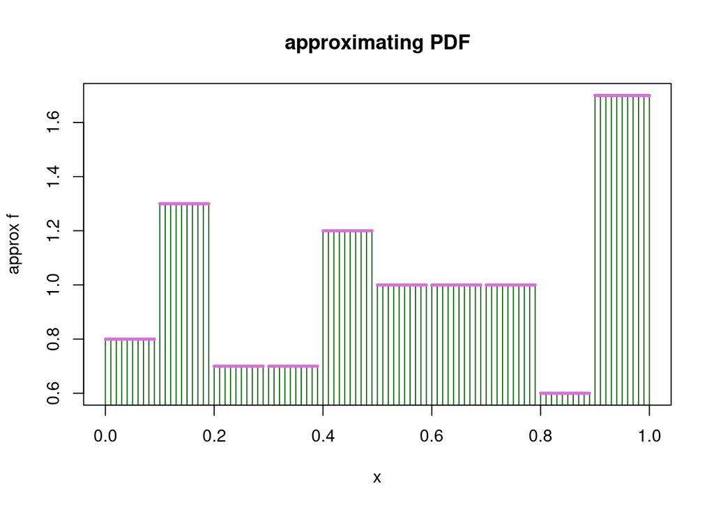

```r
#points in which we compute the approximating function
x <- seq(0, 1, 0.01)

#approximating function
f_hat = sapply(x, function(x) approx_f(h, x, pigreco))

#plot: type="h" allow to understand better its shape
plot(x, f_hat, xlim=c(0,1), col="darkgreen", type = "h", main = "approximating PDF", ylab = "approx f")

#I add the segments to visualize better the steps
segments(0.9, pigreco[10]/h, 1, pigreco[10]/h, col = "orchid", lwd = 3)
for(i in 0:9){
  segments(i*h,pigreco[i+1]/h, i*h + 0.09,pigreco[i+1]/h, col = "orchid", lwd = 3)
}
```

Just to have a visualization of what we are doing, we keep going with this tiny example and we have also tried to plot its CDF. Since the approximating density is a stepwise function, we expect that also its CDF is stepwise. Instead to use the function *integrate*, we have done the cumulative sum of the parameter vector because the area under each step is equal to $h \cdot \frac{\pi_j}{h} = \pi_j$ so it is like we are summing an area after the other. The difference between two consecutive step, for example j and j+1, is equal to the value of $\pi_{j+1}$. The height of the last step is 1.

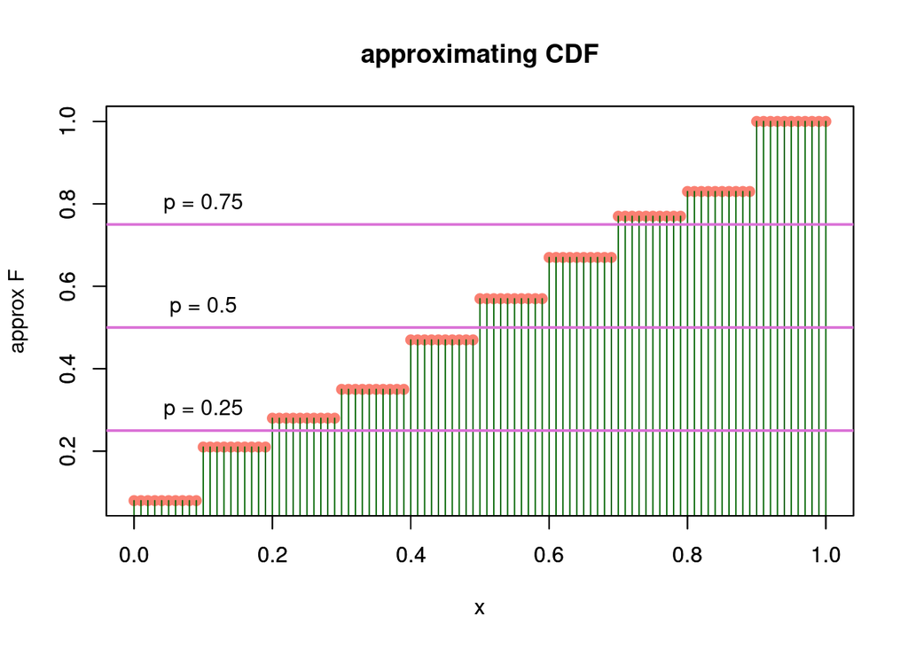

```r
approx_F <- function(pigreco){

  #input: parameter vector
  #output: plot of the approximating CDF

  #I compute CDF doing the cumulative sum.
  #I add one at the end just to have a vector of length 101 as x
  f_grande <- c(rep(cumsum(pigreco), each = 10), 1)

  plot(x,f_grande, type = "p", col = "salmon", lwd = 1, pch= 19, main = "approximating CDF", ylab="approx F")

  #with par I admit another plot in the same figure
  par(new=TRUE)
  plot(x,f_grande, type = "h", col = "darkgreen", lwd = 1, ylab="")

  #plot the horizontal line to visualize the first, second and third quartile
  abline(0.25,0, col = "orchid", lwd = 2)
  text(0.1,0.3,"p = 0.25")

  abline(0.5,0, col = "orchid", lwd = 2)
  text(0.1,0.55,"p = 0.5")

  abline(0.75,0, col = "orchid", lwd = 2)
  text(0.1,0.8,"p = 0.75")
}
#computing the CDF for my example
approx_F(pigreco)
```

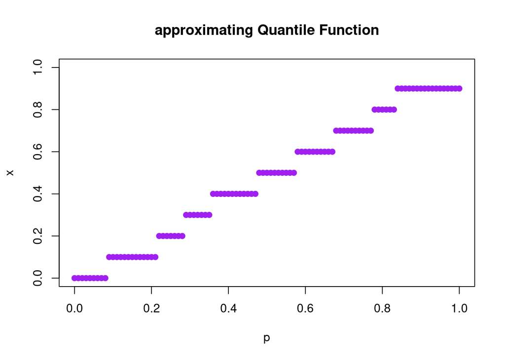

```r
approx_quantil <- function(h, p, pigreco){
  #input:
  #h: length of the bin
  #p: tail area
  #pigreco: parameter vector

  #output: quantile of p

  #compute the cumulative sum of the vector of parameters pigreco
  cdf <- cumsum(pigreco)

  #number of bins
  N = ceiling(1/h)

  #In this case the quantile function will be always equal to the start of the step, so I have also compute the cumsum of the length of the bins
  h_list = rep(h, N)
  h_list = cumsum(h_list)

  #until the first height the function will be zero
  if (p <= pigreco[1]){
    return(0)

  }else{

    for (i in 1:(N-1)){

      #I look for the first bin that cover the given tail area
      if((p > cdf[i]) & (p <= cdf[i+1])){

        #it will return the starting point of the bin
        return(h_list[i])

        #when I find the right bin it is useless check also the others
        break
      }
    }
  }
}

#compute and plot the quantile function for my example
quantili = sapply(x, function(x) approx_quantil(h, x, pigreco))
plot(x, quantili, xlim=c(0,1), ylim = c(0,1), col="purple", type = "p", pch = 19, main = "approximating Quantile Function", ylab = "x", xlab="p")
```

```r
#with stepfun, function is not limited in 0,1
#plot(stepfun(x, c(outputs, 1)), xlim=c(0,1), col="red", verticals = FALSE,
#pch = 19, main = "Quantile function", do.point=F)
```